# Covid-19 Summary for New Haven County

2021-04-26

This table summarizes trends in each town in New Haven County. It is sorted by the category of town as developed in the report [The Five Connecticuts](https://ctdatahaven.org/sites/ctdatahaven/files/UConnCPR%20Changing%20Demographics-5%20CTs%202004.pdf): Urban Core, Urban Periphery, Wealthy, Suburban, and Rural.

For each town it shows the category, the population, the total number of cases to date, the number of recent cases per 100K of population (new cases in the last two weeks), total deaths, and the percentage of total deaths in that town attributed to nursing home residents.

Next there are two [sparklines](https://en.wikipedia.org/wiki/Sparkline) that show the trend in daily new cases and daily deaths (based on 14 day moving average). Cases and deaths are shown as a ratio to population in the town.

The purpose of this table is to make it easier to quickly scan for trends in local towns.

| town | category | total population | total cases | recent cases per 100K | total deaths | % deaths from nursing homes | town cases | town deaths |
| --- | --- | --- | --- | --- | --- | --- | --- | --- |
| New Haven | Urban Core | 130,529 | 13,690 | 397.6 | 195 | 48% |  |  |
| Waterbury | Urban Core | 108,672 | 15,723 | 607.3 | 361 | 56% |  |  |
| Ansonia | Urban Periphery | 18,860 | 1,946 | 392.4 | 27 | NA |  |  |
| Branford | Urban Periphery | 28,094 | 2,430 | 316.8 | 66 | 62% |  |  |
| Derby | Urban Periphery | 12,596 | 1,257 | 436.6 | 17 | NA |  |  |
| East Haven | Urban Periphery | 28,860 | 3,348 | 575.2 | 79 | 81% |  |  |
| Hamden | Urban Periphery | 61,206 | 5,800 | 558.8 | 184 | 66% |  |  |
| Meriden | Urban Periphery | 59,864 | 7,791 | 549.6 | 150 | 67% |  |  |
| Milford | Urban Periphery | 54,047 | 4,661 | 351.5 | 128 | 85% |  |  |
| Naugatuck | Urban Periphery | 31,481 | 3,419 | 428.8 | 91 | 90% |  |  |
| Seymour | Urban Periphery | 16,522 | 1,623 | 326.8 | 68 | 92% |  |  |
| West Haven | Urban Periphery | 54,918 | 5,865 | 458.9 | 111 | 39% |  |  |
| Bethany | Suburban | 5,504 | 404 | 308.9 | 2 | NA |  |  |
| Cheshire | Suburban | 29,208 | 2,240 | 366.3 | 51 | 54% |  |  |
| Guilford | Suburban | 22,285 | 1,416 | 327.6 | 33 | 82% |  |  |
| Madison | Suburban | 18,183 | 1,185 | 335.5 | 36 | 74% |  |  |
| Middlebury | Suburban | 7,661 | 700 | 339.4 | 19 | NA |  |  |
| North Branford | Suburban | 14,208 | 1,183 | 401.2 | 21 | NA |  |  |
| North Haven | Suburban | 23,786 | 2,266 | 348.9 | 52 | 92% |  |  |
| Orange | Suburban | 13,937 | 1,066 | 337.2 | 19 | 56% |  |  |
| Oxford | Suburban | 13,022 | 920 | 284.1 | 14 | NA |  |  |
| Prospect | Suburban | 9,736 | 902 | 626.5 | 5 | NA |  |  |
| Southbury | Suburban | 19,754 | 1,434 | 288.5 | 60 | 60% |  |  |
| Wallingford | Suburban | 44,771 | 4,439 | 417.7 | 171 | 93% |  |  |
| Wolcott | Suburban | 16,652 | 1,929 | 372.3 | 53 | NA |  |  |
| Woodbridge | Suburban | 8,868 | 576 | 169.1 | 43 | 62% |  |  |
| Beacon Falls | Rural | 6,115 | 553 | 523.3 | 6 | NA |  |  |

The first map shows cases by town in New Haven County. The second map shows the percentage of individuals below the poverty line.

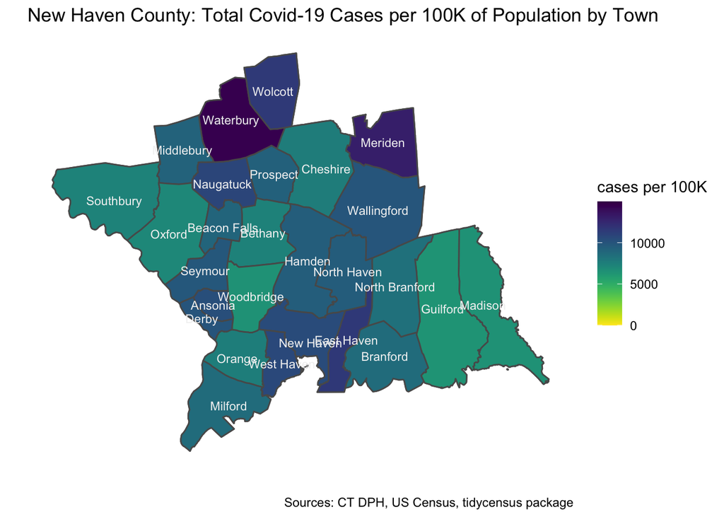

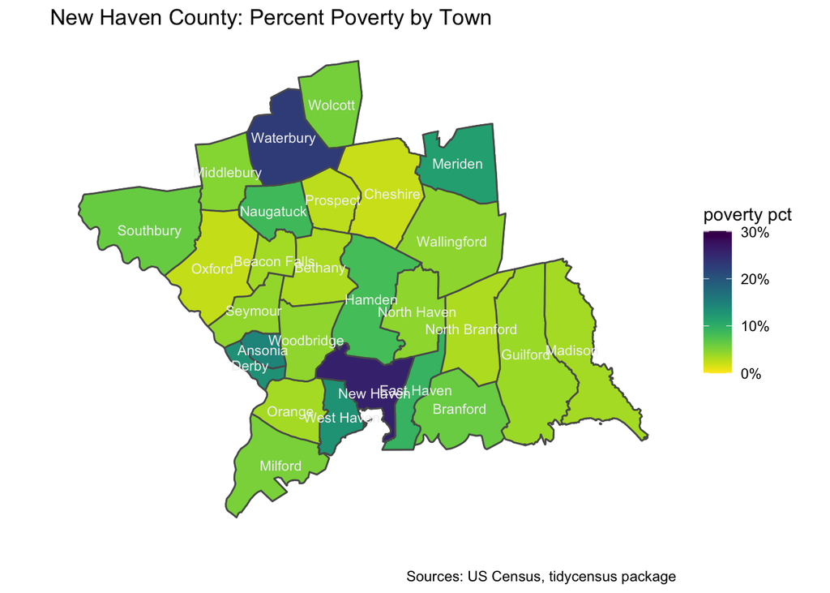